# Infinium methylation analysis

Kornelija Prokopimaite

2025-06-10

This project is for University of Bologna MSc Bioinformatics DNA/RNA Dynamics course which aims to apply a standartisised pipeline for DNA methylation data analysis generated by the Illumina HumanMethylation450 Beadchip.

The workflow: - Assess data quality - Uncovers biologically meaningful differences in methylation patterns between groups - Adress technical variability through normalisation - Highlights genomic regions of interest through differential analysis

This approach is suitable for hypothesis research into epigenetic differences between conditions, such as disease vs. control, or functional comparisons like WT vs. MUT.

### Installing required packages

```r
rm(list = ls())
options(repos = c(CRAN = "https://cran.rstudio.com/"))
if (!require("BiocManager", quietly = TRUE))
  install.packages("BiocManager")

BiocManager::install(version = "3.20")
BiocManager::install("minfi")
BiocManager::install("IlluminaHumanMethylation450kmanifest")
BiocManager::install("IlluminaHumanMethylation450kanno.ilmn12.hg19")

install.packages("factoextra")
```

```r
install.packages("qqman")
install.packages("gplots")
install.packages("future.apply")
install.packages("viridis")
install.packages("pheatmap")
```

### 1. Loading raw data

Raw data is imported into the analysis using minfi.

```r
library(minfi)
setwd('/Users/kornelijaprok/Desktop/DNA_RNA/fluorescence_info')
baseDir <- getwd()
sampleSheetFile <- file.path(baseDir, "Samplesheet_report_2024.csv")
targets <- read.metharray.sheet(baseDir, pattern = basename(sampleSheetFile))
```

```
## [1] "/Users/kornelijaprok/Desktop/DNA_RNA/fluorescence_info/Samplesheet_report_2024.csv"
```

```r
rownames(targets) <- basename(targets$Basename)
RGset <- read.metharray.exp(targets = targets)
save(RGset, file = "RGset.RData")

# Loading Illumina 450k Manifest
manifest <- read.csv("/Users/kornelijaprok/Desktop/DNA_RNA/humanmethylation450_15017482_v1-2.csv",
                     header = TRUE, skip = 7)
Illumina450Manifest_clean <- manifest[, c("AddressA_ID", "Infinium_Design_Type", "IlmnID")]
save(Illumina450Manifest_clean, file = "Illumina450Manifest_clean.RData")
```

### 2. R/G dataframes

Creating separate data frames for the red and green signal intensities extracted from the methylation array data (RGset).

```r
Red <- data.frame(getRed(RGset))
head(Red)
```

```
##          X200400320115_R01C01 X200400320115_R02C01 X200400320115_R03C01
## 10600313                  591                  742                  613
## 10600322                 4140                 4154                 4553
## 10600328                 6535                 6250                 6223
## 10600336                15752                15110                16277
## 10600345                  597                 1027                  624
## 10600353                 1464                 1381                 1863
##          X200400320115_R04C01 X200400320115_R02C02 X200400320115_R03C02
## 10600313                  577                  592                  637
## 10600322                 3965                 3248                 3933
## 10600328                 6208                 6154                 6301
## 10600336                15746                13907                15217
## 10600345                  742                  529                  458
## 10600353                 1593                 1591                 1584
##          X200400320115_R04C02 X200400320115_R05C02
## 10600313                  812                  700
## 10600322                 5749                 7030
## 10600328                 6129                 5731
## 10600336                14955                15061
## 10600345                 1674                  393
## 10600353                 1649                 1237
```

```r
Green <- data.frame(getGreen(RGset))
head(Green)
```

```
##          X200400320115_R01C01 X200400320115_R02C01 X200400320115_R03C01
## 10600313                  289                  390                  408
## 10600322                 7070                 9820                 9225
## 10600328                 6421                 7184                 6963
## 10600336                 1571                 1467                 1526
## 10600345                 5692                 6353                 7518
## 10600353                 4280                 4824                 5346
##          X200400320115_R04C01 X200400320115_R02C02 X200400320115_R03C02
## 10600313                  360                  337                  431
## 10600322                 8324                 8910                 9553
## 10600328                 7171                 6836                 6522
## 10600336                 1864                 1620                 1496
## 10600345                 6360                 6418                 6805
## 10600353                 4373                 5110                 4774
##          X200400320115_R04C02 X200400320115_R05C02
## 10600313                  428                  379
## 10600322                 7285                 7154
## 10600328                 7554                 6933
## 10600336                 1602                 3729
## 10600345                 6566                 4261
## 10600353                 5290                 4087
```

### 3. Getting probe info

This step is a detailed investigation of probe’s adress `42639338` fluorescence signals and design type (Type I or Type II) of the probe retrieved from the manifest (Illumina450Manifest_clean). A summary table (table_address) combines the probe’s fluorescence intensities and type for all samples.

Comment: Red and green fluorescence intensities vary across samples. For example, sample X200400320115_R05C02 has much lower intensities than sample X200400320115_R01C01, with a red signal of 157 and a green signal of 420. This could be due to poor quality sample. Also, all entries indicate the probe is a Type II design which means the probe uses a single fluorescence signal per methylation state. For this reason normalisation will be used later.

```r
load("Illumina450Manifest_clean.RData")
probe_address <- "42639338"

probe_red <- Red[rownames(Red) == probe_address, ]
probe_green <- Green[rownames(Green) == probe_address, ]

type_val <- Illumina450Manifest_clean$Infinium_Design_Type[
  Illumina450Manifest_clean$AddressA_ID == probe_address]

table_address <- data.frame(
  Sample = colnames(probe_red),
  Red_fluor = unlist(probe_red, use.names = FALSE),
  Green_fluor = unlist(probe_green, use.names = FALSE),
  Type = type_val,
  stringsAsFactors = FALSE
)

print(table_address)
```

```
##                 Sample Red_fluor Green_fluor Type
## 1 X200400320115_R01C01     18359       10513   II
## 2 X200400320115_R02C01     18091       12525   II
## 3 X200400320115_R03C01     18199       12242   II
## 4 X200400320115_R04C01     17519       13174   II
## 5 X200400320115_R02C02      1881        4385   II
## 6 X200400320115_R03C02      2398        2840   II
## 7 X200400320115_R04C02     15792       11014   II
## 8 X200400320115_R05C02       157         420   II
```

### 4. Creating the object MSet.raw

This processes the raw methylation array data (RGset) and converts it into a MethylSet object (MSet.raw).

```r
MSet.raw <- preprocessRaw(RGset)
MSet.raw
```

```
## class: MethylSet
## dim: 485512 8
## metadata(0):
## assays(2): Meth Unmeth
## rownames(485512): cg00050873 cg00212031 ... ch.22.47579720R
##   ch.22.48274842R
## rowData names(0):
## colnames(8): 200400320115_R01C01 200400320115_R02C01 ...
##   200400320115_R04C02 200400320115_R05C02
## colData names(8): Sample Group ... Basename filenames
## Annotation
##   array: IlluminaHumanMethylation450k
##   annotation: ilmn12.hg19
## Preprocessing
##   Method: Raw (no normalization or bg correction)
##   minfi version: 1.52.1
##   Manifest version: 0.4.0
```

### 5. Quality check

The QC plot helps identify samples with abnormal signal intensities or distributions, which could suggest poor-quality data. The detection p-value threshold used is 0.01.

Comment: Sample plot shows overall good quality.

However, failed position table shows: - Sample 200400320115_R05C02: 550 failed probes (potentially problematic). - Sample 200400320115_R02C02: 242 failed probes (moderate issues). - Other samples have fewer failed probes, with some as low as 21. This confirms sample variability and allows potential exclusion of problematic samples that have low DNA quality and/or processing issues.

Red and green fluorescence intensities of negative controls are within the expected range (log2 values up to 9), suggesting that DNA is not degraded.

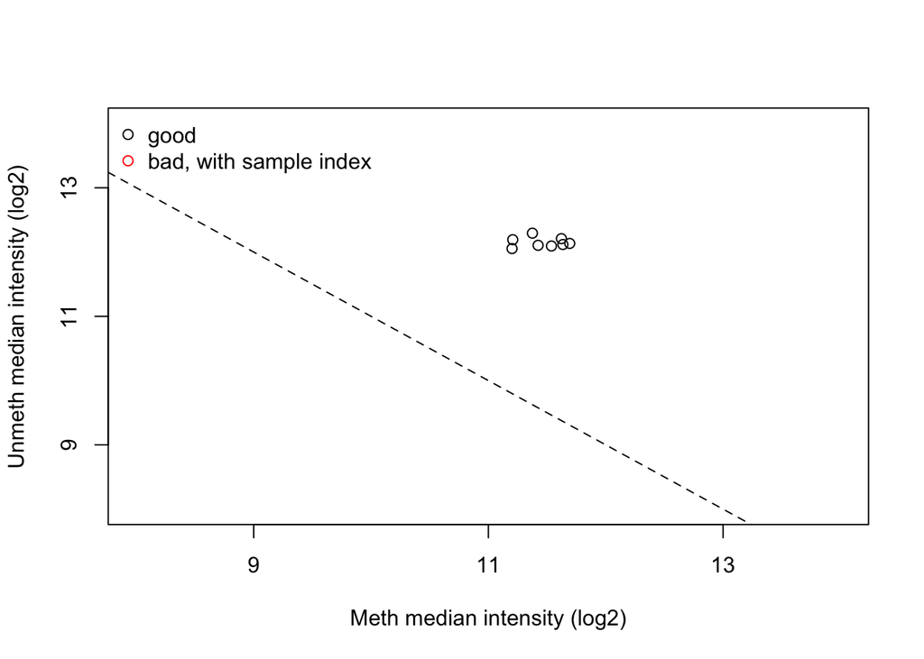

```r
qc <- getQC(MSet.raw)
plotQC(qc)
```

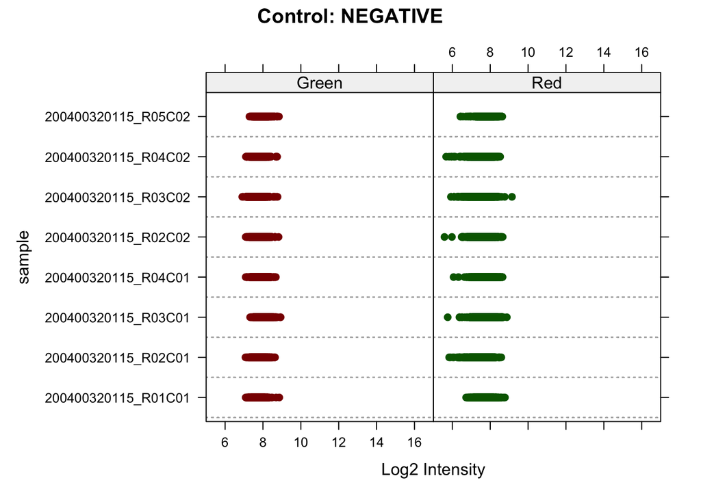

```r
controlStripPlot(RGset, controls="NEGATIVE")
```

```r
sample_names <- colnames(RGset)

detP <- detectionP(RGset)
failed <- detP > 0.01
num_failed <- colSums(failed)

df_failed <- data.frame(
  Sample = sample_names,
  Failed_Positions = num_failed,
  stringsAsFactors = FALSE
)

rownames(df_failed) <- NULL
print(df_failed)
```

```
##                Sample Failed_Positions
## 1 200400320115_R01C01               56
## 2 200400320115_R02C01               39
## 3 200400320115_R03C01               42
## 4 200400320115_R04C01               35
## 5 200400320115_R02C02              242
## 6 200400320115_R03C02              186
## 7 200400320115_R04C02               21
## 8 200400320115_R05C02              550
```

### 6. Beta and M values

Calculating and plotting the density distributions of mean Beta (methylation level) and M (log-transformed ratio) values for two groups, “WT” (wild-type) and “MUT” (mutant), based on methylation data from the MSet.raw object.

Comment: - The Beta value plot shows that WT and MUT samples exhibit bimodal distributions, with distinct peaks around Beta values ~0.1 (low methylation) and ~0.9 (high methylation). This pattern aligns with expected methylation behavior, where most probes are either hypomethylated or hypermethylated. The separation of peaks between WT and MUT indicates potential differential methylation at some loci. - The M value plot has more overlapping distributions between WT and MUT groups. Two more distinct peaks are observed within the range of -5 to 5 indicating relative methylation intensities. Subtle shifts in the density curves might indicate variations in methylation dynamics between the groups.

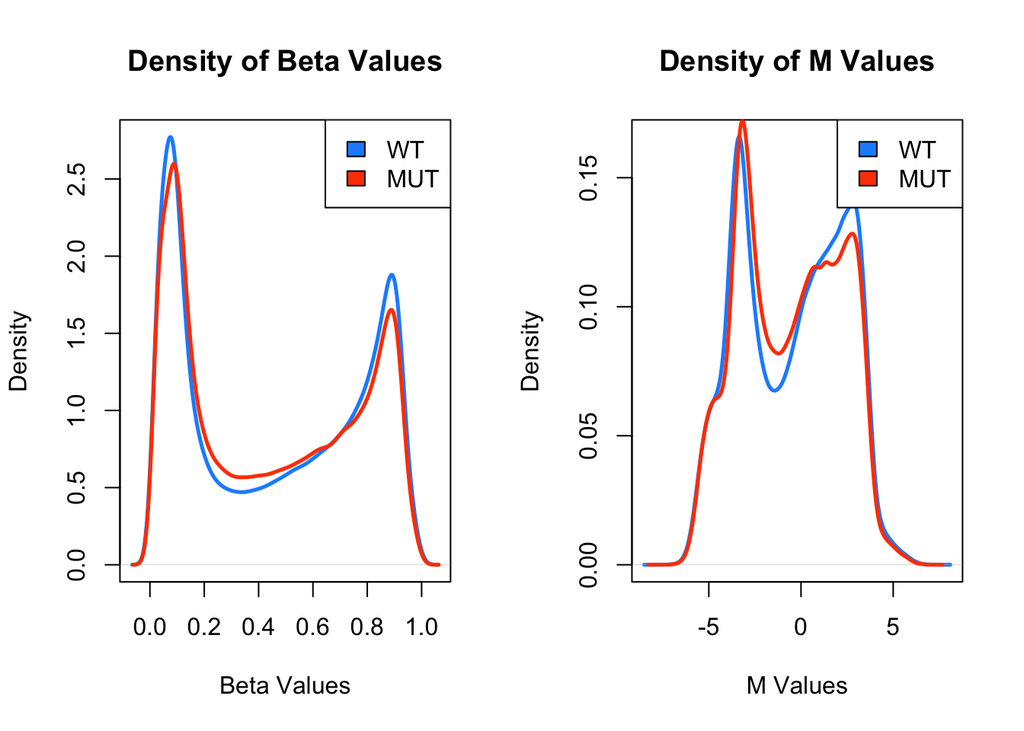

```r
# Subsetting MSet.raw for WT and MUT groups
wt <- basename(targets[targets$Group=="WT", "Basename"])
mut <- basename(targets[targets$Group=="MUT", "Basename"])
wt_set <- MSet.raw[,colnames(MSet.raw) %in% wt]
mut_set <- MSet.raw[,colnames(MSet.raw) %in% mut]

wtBeta <- getBeta(wt_set)
wtM <- getM(wt_set)
mutBeta <- getBeta(mut_set)
mutM <- getM(mut_set)

mean_wtBeta <- apply(wtBeta, MARGIN=1, mean, na.rm=TRUE)
mean_mutBeta <- apply(mutBeta, MARGIN=1, mean, na.rm=TRUE)
mean_wtM <- apply(wtM, MARGIN=1, mean, na.rm=TRUE)
mean_mutM <- apply(mutM, MARGIN=1, mean, na.rm=TRUE)

d_mean_wtBeta <- density(mean_wtBeta, na.rm=TRUE)
d_mean_mutBeta <- density(mean_mutBeta, na.rm=TRUE)
d_mean_wtM <- density(mean_wtM, na.rm=TRUE)
d_mean_mutM <- density(mean_mutM, na.rm=TRUE)
par(mfrow=c(1,2))

# Plotting density of mean Beta values
plot(d_mean_wtBeta, main="Density of Beta Values", col="#1E90FF", lwd=2.5, xlab="Beta Values", ylab="Density") # Blue for WT
lines(d_mean_mutBeta, col="#FF4500", lwd=2.5) # Orange-Red for MUT
legend('topright', legend=c("WT", "MUT"), fill=c("#1E90FF", "#FF4500"), cex=1)

# Plotting density of mean M values
plot(d_mean_wtM, main="Density of M Values", col="#1E90FF", lwd=2.5, xlab="M Values", ylab="Density") # Blue for WT
lines(d_mean_mutM, col="#FF4500", lwd=2.5) # Orange-Red for MUT
legend('topright', legend=c("WT", "MUT"), fill=c("#1E90FF", "#FF4500"), cex=1)
```

### 7. Normalisation

Evaluating and comparing raw and normalised Beta value distributions for Type I and Type II probes, using preprocessNoob normalisation to adjust for technical biases, and visualising changes in means, standard deviations, and overall Beta distributions across probe types.

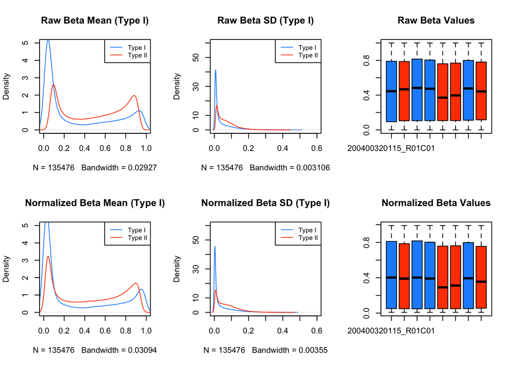

```r
dfI <- subset(Illumina450Manifest_clean, Infinium_Design_Type == "I")
dfII <- subset(Illumina450Manifest_clean, Infinium_Design_Type == "II")

beta <- getBeta(MSet.raw)
beta_I <- beta[rownames(beta) %in% dfI$IlmnID, ]
beta_II <- beta[rownames(beta) %in% dfII$IlmnID, ]

#Calculating raw means and standard deviations for each probe type:
mean_beta_I <- apply(beta_I, 1, mean, na.rm=TRUE)
mean_beta_II <- apply(beta_II, 1, mean, na.rm=TRUE)

sd_beta_I <- apply(beta_I, 1, sd, na.rm=TRUE)
sd_beta_II <- apply(beta_II, 1, sd, na.rm=TRUE)

#Calculating density estimates for means and SDs:
d_mean_beta_I <- density(mean_beta_I, na.rm=TRUE)
d_mean_beta_II <- density(mean_beta_II, na.rm=TRUE)

d_sd_beta_I <- density(sd_beta_I, na.rm=TRUE)
d_sd_beta_II <- density(sd_beta_II, na.rm=TRUE)

#Normalising the data:
MSet.norm <- preprocessNoob(RGset)

#Extracting normalised beta values:
beta_norm <- getBeta(MSet.norm)
beta_norm_I <- beta_norm[rownames(beta_norm) %in% dfI$IlmnID, ]
beta_norm_II <- beta_norm[rownames(beta_norm) %in% dfII$IlmnID, ]

#Calculating mean and SD densities for normalised data:
mean_beta_norm_I <- apply(beta_norm_I, 1, mean, na.rm=TRUE)
mean_beta_norm_II <- apply(beta_norm_II, 1, mean, na.rm=TRUE)

sd_beta_norm_I <- apply(beta_norm_I, 1, sd, na.rm=TRUE)
sd_beta_norm_II <- apply(beta_norm_II, 1, sd, na.rm=TRUE)

d_mean_beta_norm_I <- density(mean_beta_norm_I, na.rm=TRUE)
d_mean_beta_norm_II <- density(mean_beta_norm_II, na.rm=TRUE)

d_sd_beta_norm_I <- density(sd_beta_norm_I, na.rm=TRUE)
d_sd_beta_norm_II <- density(sd_beta_norm_II, na.rm=TRUE)

#Plotting the comparison:
par(mfrow=c(2,3))

group_colors <- c("WT" = "#1E90FF", "MUT" = "#FF4500")
boxplot_colors <- group_colors[as.character(targets$Group)]

plot(d_mean_beta_I, col="#1E90FF", main="Raw Beta Mean (Type I)", xlim=c(0,1), ylim=c(0,5)) # Blue for Type I
lines(d_mean_beta_II, col="#FF4500") # Orange-Red for Type II
legend("topright", legend=c("Type I","Type II"), col=c("#1E90FF","#FF4500"), lty=1, cex=0.8)

plot(d_sd_beta_I, col="#1E90FF", main="Raw Beta SD (Type I)", xlim=c(0,0.6), ylim=c(0,60)) # Blue for Type I
lines(d_sd_beta_II, col="#FF4500") # Orange-Red for Type II
legend("topright", legend=c("Type I","Type II"), col=c("#1E90FF","#FF4500"), lty=1, cex=0.8)

boxplot(beta, col=boxplot_colors, main="Raw Beta Values")

plot(d_mean_beta_norm_I, col="#1E90FF", main="Normalized Beta Mean (Type I)", xlim=c(0,1), ylim=c(0,5)) # Blue for Type I
lines(d_mean_beta_norm_II, col="#FF4500") # Orange-Red for Type II
legend("topright", legend=c("Type I","Type II"), col=c("#1E90FF","#FF4500"), lty=1, cex=0.8)

plot(d_sd_beta_norm_I, col="#1E90FF", main="Normalized Beta SD (Type I)", xlim=c(0,0.6), ylim=c(0,60)) # Blue for Type I
lines(d_sd_beta_norm_II, col="#FF4500") # Orange-Red for Type II
legend("topright", legend=c("Type I","Type II"), col=c("#1E90FF","#FF4500"), lty=1, cex=0.8)

boxplot(beta_norm, col=boxplot_colors, main="Normalized Beta Values")
```

```r
par(mfrow=c(1,1))
```

### 8. Performing PCA

This code performs PCA (Principal Component Analysis) on normalised Beta values to reduce dimensionality and visualise variability in the data, creating scatter plots of the first two principal components (PC1 and PC2) colored by biological or technical factors such as group, sex, and batch, to detect patterns, outliers, or potential confounding effects.

Comment: The main difference between the groups shows up along PC1 in the PCA plot. The wild-type (WT) samples group together pretty tightly, especially along PC2, while the mutant (MUT) samples are more spread out and don’t form a clear cluster there. Interestingly, one of the MUT samples ends up grouping close to the WT samples.

For sex, there is a clear split along PC1 between males and females. The males tend to stick together even when you look at PC2, but the females are more scattered and form a few different clusters. Some of these female clusters are actually pretty close to where the males are.

Since all the samples come from the same batch the are no noticeable differences in clustering based on batch.

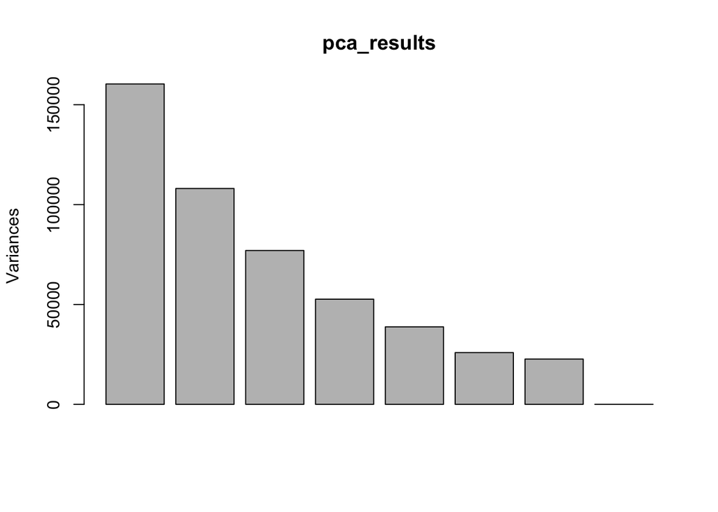

```r
pca_results <- prcomp(t(beta_norm), scale = TRUE)

plot(pca_results)
```

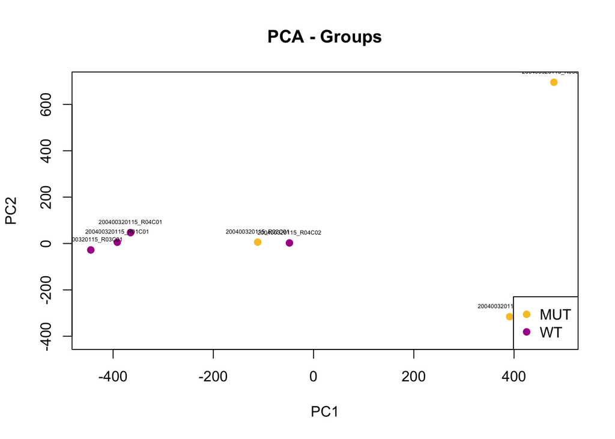

```r
targets$Group <- as.factor(targets$Group)
targets$Sex <- as.factor(targets$Sex)

if ("Slide" %in% colnames(targets)) {
  targets$Batch <- as.factor(targets$Slide)
} else if ("Sentrix_ID" %in% colnames(targets)) {
  targets$Batch <- as.factor(targets$Sentrix_ID)
} else {
  stop("Batch column not found in targets!")
}

palette(c("#FAC42A", "#AB2494"))

# Plotting PCA by Group
plot(pca_results$x[, 1], pca_results$x[, 2], cex = 1, pch = 19, col = targets$Group,
     xlab = "PC1", ylab = "PC2", main = "PCA - Groups")
text(pca_results$x[, 1], pca_results$x[, 2], labels = rownames(pca_results$x), cex = 0.4, pos = 3)
legend("bottomright", legend = levels(targets$Group), col = 1:length(levels(targets$Group)), pch = 19)
```

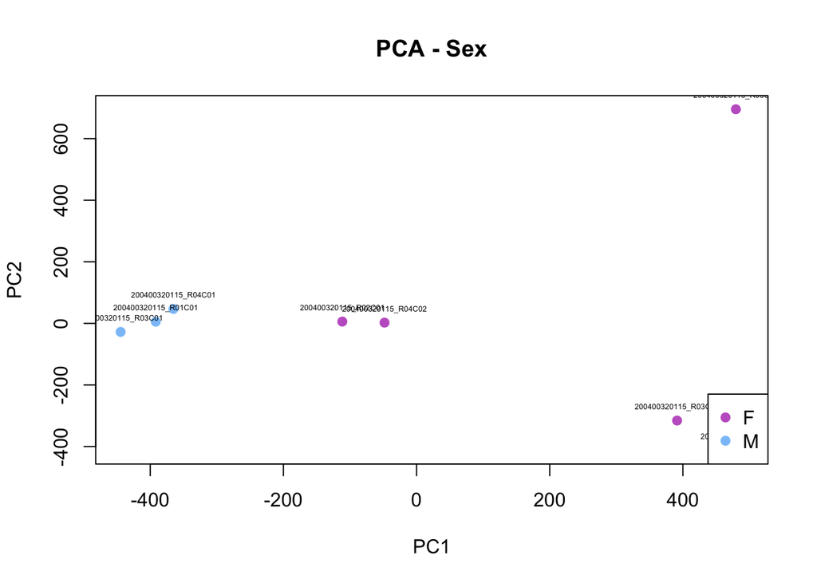

```r
# Plotting PCA by Sex
palette(c("#C364CA", "#8BC4F9"))
plot(pca_results$x[, 1], pca_results$x[, 2], cex = 1, pch = 19, col = targets$Sex,
     xlab = "PC1", ylab = "PC2", main = "PCA - Sex")
text(pca_results$x[, 1], pca_results$x[, 2], labels = rownames(pca_results$x), cex = 0.4, pos = 3)
legend("bottomright", legend = levels(targets$Sex), col = 1:length(levels(targets$Sex)), pch = 19)
```

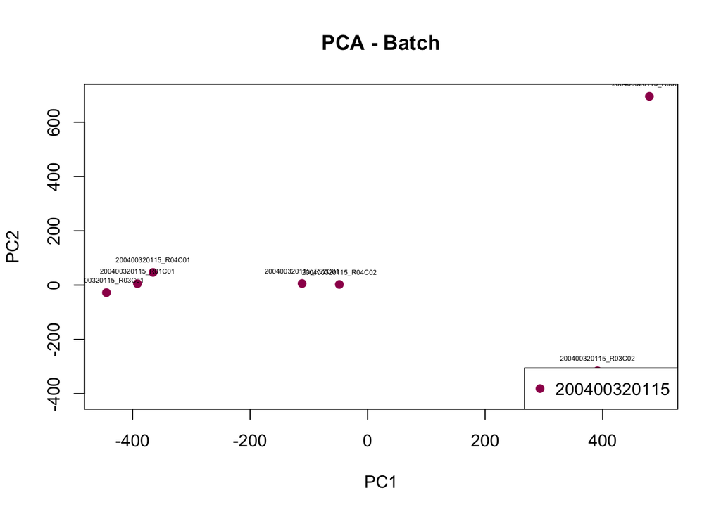

```r
# Plotting PCA by Batch
palette(c("#9e0059", "yellow", "#2c7bb6", "#d7191c", "#fdae61"))  # More colors if needed
plot(pca_results$x[, 1], pca_results$x[, 2], cex = 1, pch = 19, col = targets$Batch,
     xlab = "PC1", ylab = "PC2", main = "PCA - Batch")
text(pca_results$x[, 1], pca_results$x[, 2], labels = rownames(pca_results$x), cex = 0.4, pos = 3)
legend("bottomright", legend = levels(targets$Batch), col = 1:length(levels(targets$Batch)), pch = 19)
```

### 9. T-test

This code conducts a t-test on normalized Beta values for each probe to compare methylation levels between the ‘WT’ and ‘MUT’ groups. It adjusts the p-values using the Benjamini-Hochberg method to account for multiple testing and identifies probes with significant differences in methylation (adjusted p-value < 0.05).

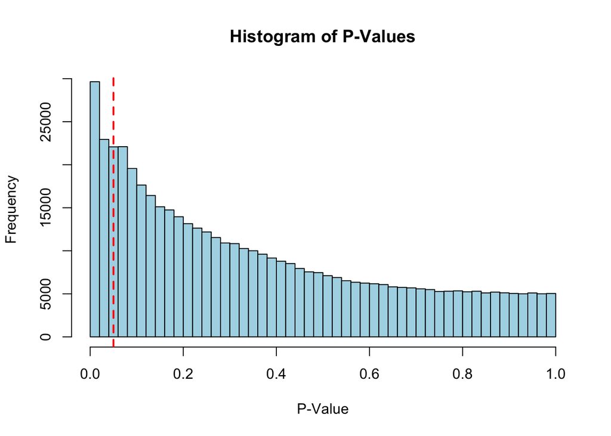

```r
targets$Group <- as.factor(targets$Group)

# Subsetting beta values for WT and MUT groups
wt_samples <- targets$Basename[targets$Group == "WT"]
mut_samples <- targets$Basename[targets$Group == "MUT"]

wt_beta <- beta_norm[, colnames(beta_norm) %in% wt_samples]
mut_beta <- beta_norm[, colnames(beta_norm) %in% mut_samples]

# Performing t-test for each probe
t_test_results <- apply(beta_norm, 1, function(probe_values) {
  t.test(probe_values[targets$Group == "WT"],
         probe_values[targets$Group == "MUT"])$p.value
})

adjusted_p_values <- p.adjust(t_test_results, method = "BH")

hist(t_test_results,
     breaks = 50,
     col = "lightblue",
     main = "Histogram of P-Values",
     xlab = "P-Value",
     ylab = "Frequency")
abline(v = 0.05, col = "red", lwd = 2, lty = 2)
```

```r
differential_methylation_results <- data.frame(
  Probe = rownames(beta_norm),
  P_Value = t_test_results,
  Adjusted_P_Value = adjusted_p_values,
  stringsAsFactors = FALSE
)
```

### 10. Multiple test correction:

Summarised number of significant probes at different thresholds, including nominal p-value < 0.05, Bonferroni correction, and BH adjustment, to assess the stringency of multiple testing corrections.

Comment: - Nominal p-values are not corrected for multiple comparisons and some of these could be false positives due to the multiple testing issue because each test is compared - in Bonferroni correction only probes with very low p-values remain significant because it divides the significance level by the total number of tests performed - BH allows some false positives and its correction is less stringent than Bonferroni. Therefore, inclusion of some false positives led to 213 significant probes as oppose to 5 in Bonferroni

```r
bonferroni_p_values <- p.adjust(t_test_results, method = "bonferroni")

bh_p_values <- p.adjust(t_test_results, method = "BH")

nominal_significant_probes <- sum(t_test_results < 0.05)
bonferroni_significant_probes <- sum(bonferroni_p_values < 0.05)
bh_significant_probes <- sum(bh_p_values < 0.05)

# Print results
cat("Nominal Significant Probes:", nominal_significant_probes, "\n")
```

```
## Nominal Significant Probes: 63437
```

```r
cat("Bonferroni Significant Probes:", bonferroni_significant_probes, "\n")
```

```
## Bonferroni Significant Probes: 5
```

```r
cat("BH Significant Probes:", bh_significant_probes, "\n")
```

```
## BH Significant Probes: 213
```

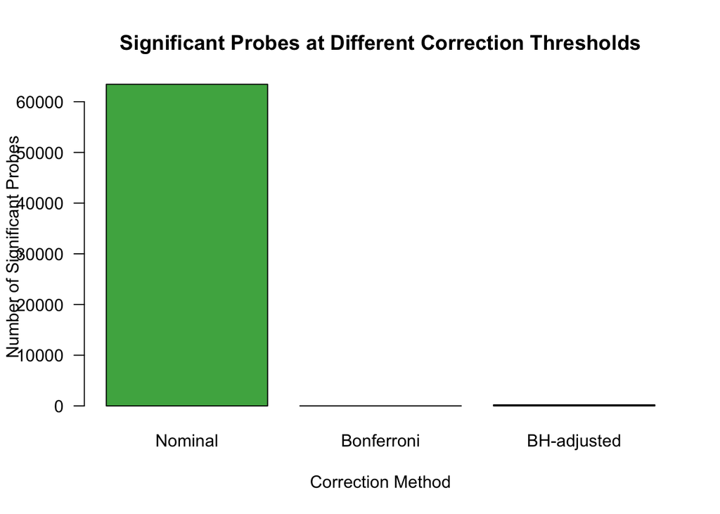

```r
significance_counts <- c(nominal_significant_probes, bonferroni_significant_probes, bh_significant_probes)
labels <- c("Nominal", "Bonferroni", "BH-adjusted")

barplot(
  height = significance_counts,
  names.arg = labels,
  col = c("#4CAF50", "#2196F3", "#FFC107"),
  main = "Significant Probes at Different Correction Thresholds",
  ylab = "Number of Significant Probes",
  xlab = "Correction Method",
  las = 1
)
```

### 11. Volcano and Manhattan plots

This code compares DNA methylation levels between wild-type (WT) and mutant (MUT) groups by calculating mean differences, then visualises the results with a volcano plot and a Manhattan plot of differential methylation probes annotated by genomic position.

Comment: - Blue horizontal line represents statistical significance cutoff at a p-value of 0.05 - Grey dots represent probes that are not statistically significant after multiple testing correction. Some probes have raw p-values below 0.05 (above the blue line) but their adjusted p-values are not significant enough to be colored red - Red dots represent probes with the strongest evidence of differential methylation between WT and MUT groups - statistically significant

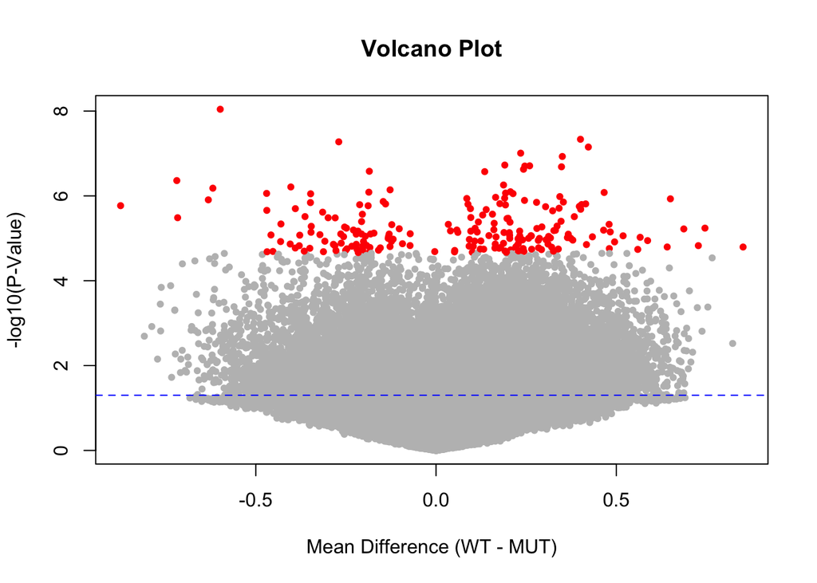

```r
targets$Basename <- basename(targets$Basename)

wt_samples <- targets$Basename[targets$Group == "WT"]
mut_samples <- targets$Basename[targets$Group == "MUT"]

wt_beta <- beta_norm[, colnames(beta_norm) %in% wt_samples, drop=FALSE]
mut_beta <- beta_norm[, colnames(beta_norm) %in% mut_samples, drop=FALSE]

mean_difference <- rowMeans(wt_beta, na.rm=TRUE) - rowMeans(mut_beta, na.rm=TRUE)
differential_methylation_results$Mean_Difference <- mean_difference

# Volcano plot
plot(
  x = differential_methylation_results$Mean_Difference,
  y = -log10(differential_methylation_results$P_Value),
  pch = 20,
  col = ifelse(differential_methylation_results$Adjusted_P_Value < 0.05, "red", "gray"),
  xlab = "Mean Difference (WT - MUT)",
  ylab = "-log10(P-Value)",
  main = "Volcano Plot"
)
abline(h = -log10(0.05), col = "blue", lty = 2)
```

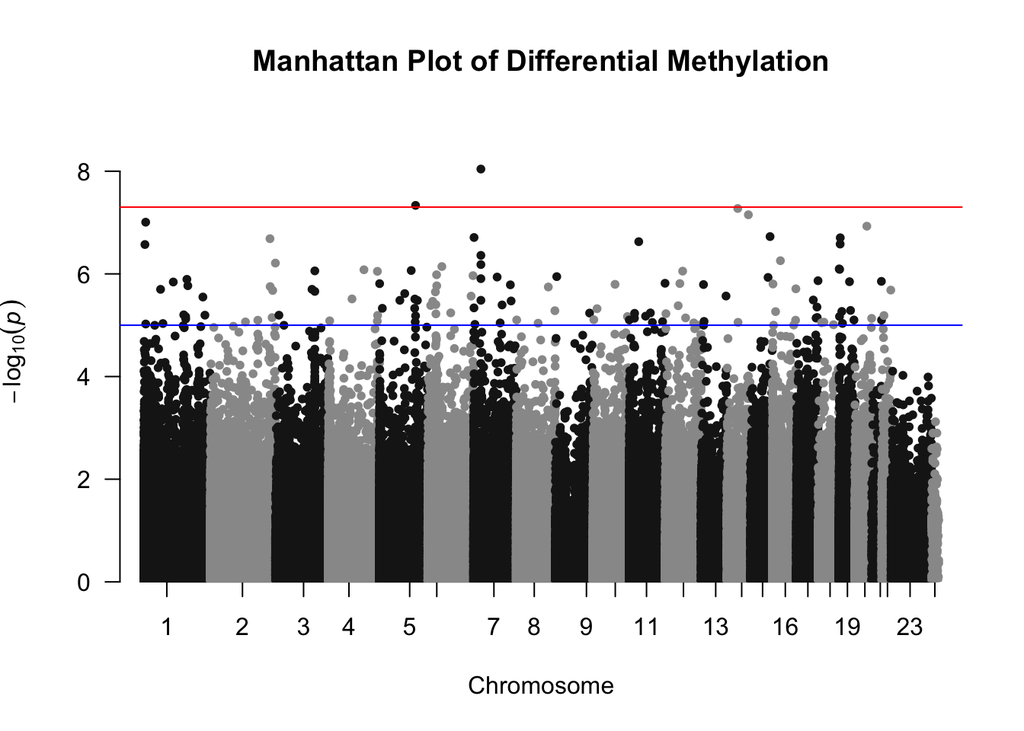

```r
#Manhattan plot
library(qqman)
library(IlluminaHumanMethylation450kanno.ilmn12.hg19)
annotation <- getAnnotation(IlluminaHumanMethylation450kanno.ilmn12.hg19)

annotated_results <- merge(
  differential_methylation_results,
  annotation[, c("Name", "chr", "pos")],
  by.x = "Probe",
  by.y = "Name",
  all.x = TRUE
)

annotated_results$CHR <- gsub("^chr", "", annotated_results$chr)
annotated_results$CHR[annotated_results$CHR == "X"] <- "23"
annotated_results$CHR[annotated_results$CHR == "Y"] <- "24"
annotated_results$CHR[annotated_results$CHR %in% c("MT", "M")] <- "25"
annotated_results$CHR <- as.numeric(annotated_results$CHR)

# Filtering rows with valid CHR, pos, and P-value
valid <- !is.na(annotated_results$CHR) & !is.na(annotated_results$pos) & !is.na(annotated_results$P_Value) &
  annotated_results$P_Value > 0 & annotated_results$P_Value <= 1

annotated_results_clean <- annotated_results[valid, ]

manhattan_data <- data.frame(
  SNP = annotated_results_clean$Probe,
  CHR = annotated_results_clean$CHR,
  BP = annotated_results_clean$pos,
  P = annotated_results_clean$P_Value
)

# Removing duplicated SNPs
manhattan_data <- manhattan_data[!duplicated(manhattan_data$SNP), ]

if(nrow(manhattan_data) > 0) {
  manhattan(manhattan_data, main = "Manhattan Plot of Differential Methylation")
} else {
  cat("No valid data available to plot Manhattan plot.\n")
}
```

### 12. Heatmap

This creates a heatmap visualisation of the top 100 most significantly differentially methylated probes, showing their normalised and scaled methylation values across samples, with sample group annotations.

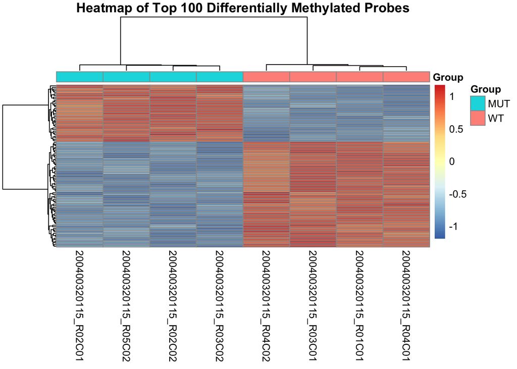

```r
library(pheatmap)

top_probes <- head(differential_methylation_results[order(differential_methylation_results$P_Value), ], 100)$Probe
heatmap_data <- beta_norm[top_probes, , drop = FALSE]
heatmap_data_scaled <- t(scale(t(heatmap_data)))
annotation_col <- data.frame(Group = targets$Group)
rownames(annotation_col) <- targets$Basename

pheatmap(
  heatmap_data_scaled,
  cluster_rows = TRUE,
  cluster_cols = TRUE,
  show_rownames = FALSE,
  annotation_col = annotation_col,
  main = "Heatmap of Top 100 Differentially Methylated Probes"
)
```